# Forecasting of France's electrical energy consumption

**Authors: Bouvier Oscar, Gallier Hugues, Hofmann Guillaume, Ilbert Romain, Katsoulakis Christos**

Optimally distributing electrical energy to almost 30 million households is a constant challenge for French power grid engineers. The most obvious constraint comes from the limits of the laws of physics, which make it very difficult to store the energy produced by French power plants. Thus, the power grid must constantly maintain a balance between consumption and production. An excess of production must be obligatorily evacuated and is the cause of financial losses, while a lack of production can lead to power outages.

New difficulties are added with the development of intermittent energies (wind turbines, solar panels) whose production or lack of production must be compensated by the contribution of controllable energy sources (nuclear power plants, hydraulic dams).

This is why a reliable forecast of French electricity consumption is a crucial asset for anticipate needs in order to avoid blackouts and be able to intelligently distribute production over the various available energy sources.

# Table of content

- Presentation of problem
  - The forecast
  - Performance indicator
- Data Exploration
  - Presentation of features
  - Target
- Data Analysis
  - Co-evolution of variables
  - Bivariate analysis
- Starting kit
- Submission

# Presentation of problem

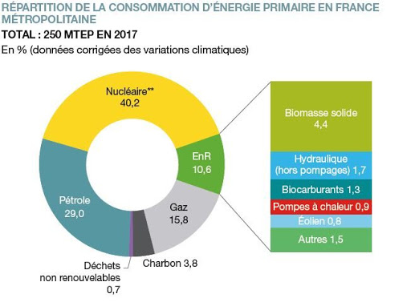

[figure not shown]

This electricity consumption follows a seasonal dynamic. On a large time scale, it is higher in winter, particularly because of the cold and longer nights. Similarly, over a day, consumption is higher in the morning and in the evening.

Thus, the production of electricity must be able to constantly adjust to consumption. Its storage is difficult because the existing devices are inefficient and expensive. This balancing function is supervised by a transmission system operator who constantly monitors the adequacy between production and consumption. In France, this operator is RTE, which carries out balancing through its Centre National d'Exploitation Système (CNES).

## The forecast

This control process is stratified according to several time horizons. Forecasts are made over 2 years, 1 year, 1 month, 1 week and from the day before to the day after with increasing precision.

Several factors influence the change in demand :

- for the annual cycle : the variation of the seasons (the winter/summer ratio is 2.1 on average and can go up to 2.44)
- for the weekly cycle : five fairly similar working days and a weekend with significantly lower consumption
- for the daily cycle : one peak in the morning around 9:00 am and a second one in the evening around 7:00 pm
- temperature variations that result in changes in the use of electric heating in winter or air conditioning in summer
- cloudiness (cloud cover) influences the use of lighting.
- economic activity: decrease in times of crisis, lows at weekends or during school vacations

Based on this forecast, an auction process is organized every day. The energy producers communicate their price proposals for each of their power plants and for each half-hour of the following day. They continuously adjust the price according to the remaining stock and the operation of their power plant.

Examples :

- A power plant with a rigid operation, i.e. whose start-up process can take several hours, is better off selling its prices during off-peak hours to continue producing without having to stop (like coal-fired power plants).
- A power plant whose stock (of coal for example) remains high at the end of Winter has interest to sell its prices to liquidate its stock otherwise it will be lost.

Electricity forecasting is therefore fundamental for a developed country like France. Bad forecasts or catastrophic weather conditions could lead to blackouts as was the case in France in December 1999 where violent storms knocked down 23,000 power poles and high-voltage pylons, and caused the shutdown of 3 nuclear power plants.

## Performance indicator for forecasting prediction of energy consumption

In order to measure the performance of our model, the indicator that is chosen is the MARE (which stands for Mean Absolute Relative Error) also known as the MARD (Mean Absolute Relative Deviation) and represents the average of absolute error relatively to the value of the target data.

For a single prediction at time t of $\hat{y}_t$ of $y_t$, we can define the MARE-loss as following :

$$\ell_{MARE}({y}_t,y_t) = \left\lvert{\frac{\hat{y}_t - y_t}{y_t}}\right\rvert$$

Then the objective function to minimize for our predictor is the following quantity :

$$\frac{1}{T} \sum_{t=1}^{T} \ell_{MARE}({y}_t,y_t) = \frac{1}{T} \sum_{t=1}^{T} \left\lvert{\frac{\hat{y}_t - y_t}{y_t}}\right\rvert $$

In real world applications, the MARE is frequently used when the quantity to predict is known to remain way above zero which is the case for electricity consumption. More generally, it has been argued that the MARE is very adapted for forecasting applications, especially in situations where enough data are available.

In practice, the MARE is used because of its very intuitive interpretation in terms of relative error, and in cases where the sensitivity to forecast error is more about relative variations than absolute variations.

MARE is currently the quality measure used for energy consumption forecasts in France's energy companies (EdF, GdF).

# Data Exploration

```python
import numpy as np
import pandas as pd
import datetime as dt
```

## Load data

The procedure is based on the first approach described at this link: https://medium.com/@simonprdhm/2-ways-to-upload-csv-files-to-google-colab-4d29ffa9db85

Download the file data.csv on your computer. Then, run the following line of code and click on "Select. fichiers". There you can select the file that you just have downloaded. (wait for around one minute to complete the download)

```python
colab = False
```

```python
if colab:
    from google.colab import files
    data_to_load = files.upload()
```

Then run the following to read the file in the data.frame "data"

```python
if colab:
    import io
    data = pd.read_csv(io.BytesIO(data_to_load['data.csv']))

else:
    data = pd.read_csv('data/data.csv')
```

## Presentation of features

The target to be predicted is the electrical consumption in watts hour (Wh) of the extraction points. This variable is called **comsuption** and is available at half an hour intervals from January 1st 2018 to September 30th 2020.

Availables features are:

- **horodate:** Date given in intervals of half an hour
- **vac_zone_A**, **vac_zone_B** and **vac_zone_C:** In France, dates of school holydays differ depending on the geographical area. France is thus divided into three zones for school holydays: zone A (academies of Besançon, Bordeaux, Clermont-Ferrand, Dijon, Grenoble, Limoges, Lyon, Poitiers), zone B (academies of Aix-Marseille, Amiens, Caen, Lille, Nancy-Metz, Nantes, Nice, Orléans-Tours, Reims, Rennes, Rouen, Strasbourg) and zone C (academies of Créteil, Montpellier, Paris, Toulouse, Versailles). Three indicators indicate whether the date given by horodate corresponds to the school vacation period of the given area.
- **non_working_day:** Indicator indicating the date is a bank holiday.
- **temperature_ORLY**, **temperature_MARSEILLE**, **temperature_LYON**, **temperature_TOULOUSE**, **temperature_NICE**, **temperature_NANTES**, **temperature_MONTPELLIER**, **temperature_STRASBOURG**, **temperature_BORDEAUX**, **temperature_LILLE** and **temperature_RENNES:** Average temperature in Celsius recorded in different cities (the city in consideration is indicated in the variable name).
- **wind_ORLY**, **wind_MARSEILLE**, **wind_LYON**, **wind_TOULOUSE**, **wind_NICE**, **wind_NANTES**, **wind_MONTPELLIER**, **wind_STRASBOURG**, **wind_BORDEAUX**, **wind_LILLE** and **wind_RENNES:** Average wind speed in meter/second recorded in different cities (he city in consideration is indicated in the variable name).
- **humidity_ORLY**, **humidity_MARSEILLE**, **humidity_LYON**, **humidity_TOULOUSE**, **humidity_NICE**, **humidity_NANTES**, **humidity_MONTPELLIER**, **humidity_STRASBOURG**, **humidity_BORDEAUX**, **humidity_LILLE** and **humidity_RENNES:** Average humidity rate in % recorded in different cities (the city in consideration is indicated in the variable name).

Data were obtained from the following sources:

- Electrical consumption: https://data.enedis.fr/explore/dataset/conso-sup36/information/?disjunctive.profil&disjunctive.secteur_activite
- Holidays: https://www.data.gouv.fr/fr/datasets/vacances-scolaires-par-zones/
- Bank holidays https://www.data.gouv.fr/fr/datasets/jours-feries-en-france/
- Meteorology: https://public.opendatasoft.com/explore/dataset/donnees-synop-essentielles-omm/api/?flg=fr&sort=date

```python
data.head()
```

|  | horodate | consumption | vac_zone_A | vac_zone_B | vac_zone_C | non_working_day | weekend | temperature_ORLY | wind_ORLY | humidity_ORLY | ... | humidity_STRASBOURG | temperature_BORDEAUX | wind_BORDEAUX | humidity_BORDEAUX | temperature_LILLE | wind_LILLE | humidity_LILLE | temperature_RENNES | wind_RENNES | humidity_RENNES |
| --- | --- | --- | --- | --- | --- | --- | --- | --- | --- | --- | --- | --- | --- | --- | --- | --- | --- | --- | --- | --- | --- |
| 0 | 2018-01-01 00:00:00+01:00 | 1.245527e+10 | 1 | 1 | 1 | 1 | 0 | 8.4 | 7.00 | 72.0 | ... | 73.0 | 9.80 | 6.80 | 82.0 | 7.90 | 12.40 | 73.00 | 8.2 | 5.80 | 78.0 |
| 1 | 2018-01-01 00:30:00+01:00 | 1.242073e+10 | 1 | 1 | 1 | 1 | 0 | 8.4 | 7.00 | 72.0 | ... | 73.0 | 9.80 | 6.80 | 82.0 | 7.90 | 12.40 | 73.00 | 8.2 | 5.80 | 78.0 |
| 2 | 2018-01-01 01:00:00+01:00 | 1.234427e+10 | 1 | 1 | 1 | 1 | 0 | 8.4 | 7.00 | 72.0 | ... | 73.0 | 9.80 | 6.80 | 82.0 | 7.90 | 12.40 | 73.00 | 8.2 | 5.80 | 78.0 |
| 3 | 2018-01-01 01:30:00+01:00 | 1.227482e+10 | 1 | 1 | 1 | 1 | 0 | 8.3 | 6.97 | 71.5 | ... | 72.5 | 9.68 | 6.45 | 82.0 | 7.62 | 11.68 | 74.83 | 8.1 | 5.67 | 78.0 |
| 4 | 2018-01-01 02:00:00+01:00 | 1.227774e+10 | 1 | 1 | 1 | 1 | 0 | 8.2 | 6.93 | 71.0 | ... | 72.0 | 9.57 | 6.10 | 82.0 | 7.33 | 10.97 | 76.67 | 8.0 | 5.53 | 78.0 |

5 rows × 40 columns

```python
print("The data contain", data.shape[0], "observations and", data.shape[1], "variables.")
```

```
The data contain 48190 observations and 40 variables.
```

```python
data.info()
```

```
<class 'pandas.core.frame.DataFrame'>
RangeIndex: 48190 entries, 0 to 48189
Data columns (total 40 columns):
 #   Column                   Non-Null Count  Dtype
---  ------                   --------------  -----
 0   horodate                 48190 non-null  object
 1   consumption              48190 non-null  float64
 2   vac_zone_A               48190 non-null  int64
 3   vac_zone_B               48190 non-null  int64
 4   vac_zone_C               48190 non-null  int64
 5   non_working_day          48190 non-null  int64
 6   weekend                  48190 non-null  int64
 7   temperature_ORLY         48190 non-null  float64
 8   wind_ORLY                48190 non-null  float64
 9   humidity_ORLY            48190 non-null  float64
```

[output cut: 32 more lines]

## Target

The variable to be predicted is **consumption** that is the electrical consumption in watts per hour of the extraction points. We first look at the evolution of electric consumption depending on the time.

We define below a generic function to plot time series.

```python
def plot_time_series(data, variables, start=None, end=None,
                     frequency=None, method="mean", subplots=False,
                     grid=False, figsize=(12, 5), title="Time Series"):
    """Plot time series.

    Parameters
    ----------
    data : data.frame
    The data.frame containing the data.

    variables : list
    The list of variables to plot.

    start : date (default None)
    Date on which the plotting starts.

    end : date (default None)
    Date on which the plotting ends.

    frequency : 'D', 'M', 'Y'... (default None)
    Frequency at which variables are plotted.

    method : 'mean', 'sum', 'min', 'max' (default 'mean')
    Method used when data are aggregated by date

    subplots : boolean (default False)
    Make separate subplots for each variables.

    grid : boolean (default False)
    Axis grid lines.

    figsize : a tuple (width, height) in inches (default (12,5))
    Size of a figure object.

    title : string (default "Time Series")
    Title to use for the plot.
    """

    data_plot = data[["horodate"] + variables].copy()
    data_plot["horodate"] = pd.to_datetime(data_plot["horodate"], utc=True)
    data_plot = data_plot.set_index("horodate")

    data_plot = data_plot[start:end]

    if frequency is None:
        data_plot.plot(subplots=subplots, grid=grid, figsize=figsize, title=title)
    else:
        if method=='mean':
            data_plot.resample(frequency).mean().plot(subplots=subplots,
                                                      grid=grid, figsize=figsize,
                                                      title=title)
        elif method=='sum':
            data_plot.resample(frequency).sum().plot(subplots=subplots, grid=grid, figsize=figsize,
                                                     title=title)
        elif method=='min':
            data_plot.resample(frequency).min().plot(subplots=subplots, grid=grid, figsize=figsize,
                                                     title=title)
        elif method=='max':
            data_plot.resample(frequency).max().plot(subplots=subplots, grid=grid, figsize=figsize,
                                                     title=title)
        else:
            print("method should be 'mean', 'sum', 'min' or 'max'")
```

To begin the evolution of electricity consumption in France can be observed from January 1st 2018 to September 30th 2020 with a time step of 30 minutes (smallest granularity given by the data). The seasonal character of the electricity consumption can be seen with higher electricity consumption in winter than in summer, except for Christmas holidays. In addition, the effects of the first lockdown in France due to the covid-19 crisis can be observed in March and April 2020 by a drop in electric consumption.

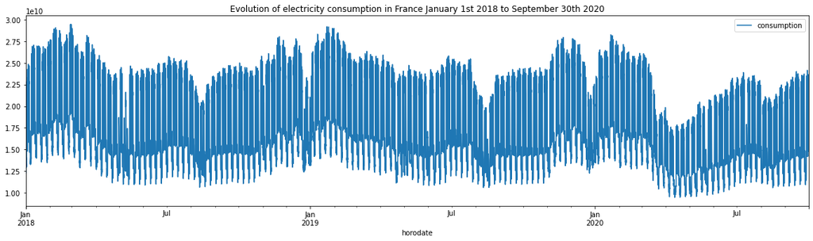

```python
plot_time_series(data, variables=["consumption"], figsize=(20,5),
                 title="Evolution of electricity consumption in France January 1st 2018 to September 30th 2020")
```

To better observe the seasonal effects, the mean monthly electric consumption can be plotted.

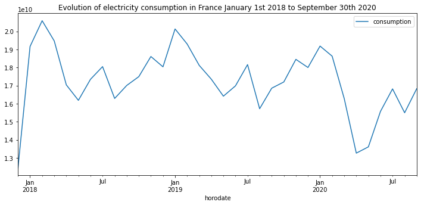

```python
plot_time_series(data, variables=["consumption"], frequency='M',
                 title="Evolution of electricity consumption in France January 1st 2018 to September 30th 2020")
```

To better observe the weekly cycle, electric consumption can be observed during two weeks (for instance from Monday 29th 2018 January to Sunday 12th February 2018). As presented in the introduction, the electric consumption is lower the week-end than the rest of the week.

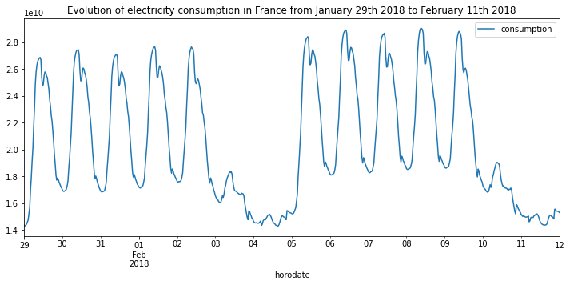

```python
plot_time_series(data, variables=["consumption"], start="2018-01-29 00:00:00+00:00",
                 end="2018-02-12 00:00:00+00:00",
                 title="Evolution of electricity consumption in France from January 29th 2018 to February 11th 2018")
```

Lastly we can observe the daily cycle by looking the electric consumption over two days. The electric consumption is higher the day than the night with two peaks : one the morning and one the afternoon.

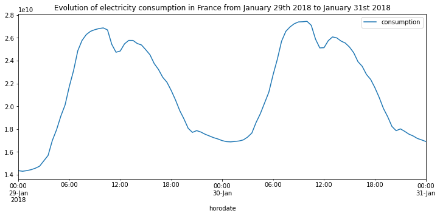

```python
plot_time_series(data, variables=["consumption"], start="2018-01-29 00:00:00+00:00",
                 end="2018-01-31 00:00:00+00:00",
                 title="Evolution of electricity consumption in France from January 29th 2018 to January 31st 2018")
```

# Data Analysis

After observing the cyclical effects of electric consumption depending on time, one can look at how electric consumption is related to other data such as temperature, humidity and wind. For instance, the meteorological conditions of Orly are plotted.

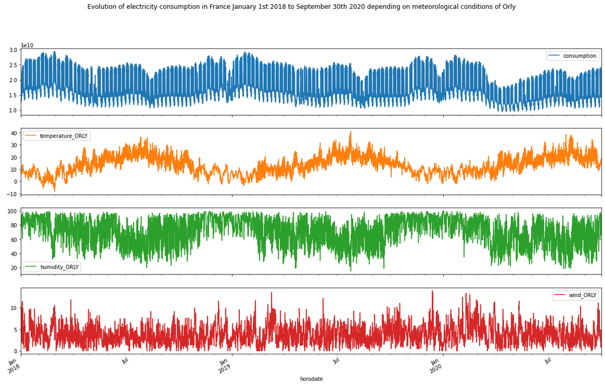

```python
plot_time_series(data, variables=["consumption", "temperature_ORLY", "humidity_ORLY", "wind_ORLY"], figsize=(20,12), subplots=True,
                 title="Evolution of electricity consumption in France January 1st 2018 to September 30th 2020 depending on meteorological conditions of Orly")
```

The following function has been implemented to easily interact with the time series.

**Important note:** In order to correctly see the dynamic time series, please run this notebook.

```python
import ipywidgets as widgets
import pandas as pd
from datetime import datetime
import matplotlib.pyplot as plt

from ipywidgets import interact


start_date = datetime(2018, 1, 1)
end_date = datetime(2020, 9, 30)

dates = pd.date_range(start_date, end_date, freq='D')

options = [(date.strftime(' %d %b %Y '), date) for date in dates]
index = (0, len(options)-1)

selection_range_slider = widgets.SelectionRangeSlider(
    options=options,
    index=index,
    description='Dates',
    orientation='horizontal',
    layout={'width': '500px'}
)

def plot_date_range(date_range, Variable_1='temperature_ORLY', Variable_2='wind_ORLY', Variable_3='humidity_ORLY'):
    data_plot = data[["horodate"] + ['consumption', Variable_1, Variable_2, Variable_3]].copy()
    data_plot["horodate"] = pd.to_datetime(data_plot["horodate"], utc=True)
    data_plot = data_plot[data_plot.horodate.between(str(date_range[0].date()), str(date_range[1].date()))]

    fig, axs = plt.subplots(4, 1, figsize = (20, 12))
    axs[0].plot(data_plot[["horodate"]], data_plot[["consumption"]])
    axs[1].plot(data_plot[["horodate"]], data_plot[[Variable_1]])
    axs[2].plot(data_plot[["horodate"]], data_plot[[Variable_2]])
    axs[3].plot(data_plot[["horodate"]], data_plot[[Variable_3]])

interact(
    plot_date_range,
    Variable_1=[('Temperature Orly', 'temperature_ORLY'),
              ('Temperature Marseille','temperature_MARSEILLE'),
              ('Temperature  Lyon', 'temperature_LYON'),
              ('Temperature  Toulouse', 'temperature_TOULOUSE'),
              ('Temperature  Nice', 'temperature_NICE'),
              ('Temperature  Nantes', 'temperature_NANTES'),
              ('Temperature  Montpellier', 'temperature_MONTPELLIER'),
              ('Temperature  Strasbourg', 'temperature_STRASBOURG'),
              ('Temperature  Bordeaux', 'temperature_BORDEAUX'),
              ('Temperature  Lille', 'temperature_LILLE'),
              ('Temperature  Rennes', 'temperature_RENNES')],
    Variable_2=[('Wind Orly', 'wind_ORLY'),
              ('Wind Marseille','wind_MARSEILLE'),
              ('Wind  Lyon', 'wind_LYON'),
              ('Wind  Toulouse', 'wind_TOULOUSE'),
              ('Wind  Nice', 'wind_NICE'),
              ('Wind  Nantes', 'wind_NANTES'),
              ('Wind  Montpellier', 'wind_MONTPELLIER'),
              ('Wind  Strasbourg', 'wind_STRASBOURG'),
              ('Wind  Bordeaux', 'wind_BORDEAUX'),
              ('Wind  Lille', 'wind_LILLE'),
              ('Wind  Rennes', 'wind_RENNES')],
    Variable_3=[('Humidity Orly', 'humidity_ORLY'),
              ('Humidity Marseille','humidity_MARSEILLE'),
              ('Humidity  Lyon', 'humidity_LYON'),
              ('Humidity  Toulouse', 'humidity_TOULOUSE'),
              ('Humidity  Nice', 'humidity_NICE'),
              ('Humidity  Nantes', 'humidity_NANTES'),
              ('Humidity  Montpellier', 'humidity_MONTPELLIER'),
              ('Humidity  Strasbourg', 'humidity_STRASBOURG'),
              ('Humidity  Bordeaux', 'humidity_BORDEAUX'),
              ('Humidity  Lille', 'humidity_LILLE'),
              ('Humidity  Rennes', 'humidity_RENNES')],
    date_range=selection_range_slider
)
```

```
<function __main__.plot_date_range(date_range, Variable_1='temperature_ORLY', Variable_2='wind_ORLY', Variable_3='humidity_ORLY')>
```

# Bivariate analysis

```python
temperature = [col for col in data.columns if col.startswith('temperature')]
wind = [col for col in data.columns if col.startswith('wind')]
humidity = [col for col in data.columns if col.startswith('humidity')]
data_temp = data[temperature]
data_wind = data[wind]
data_hum = data[humidity]
```

```python
temperature_FRANCE = data[temperature].mean(axis=1)
wind_FRANCE = data[wind].mean(axis=1)
humidity_FRANCE = data[humidity].mean(axis=1)
```

```python
data.insert(40,"temperature_FRANCE",temperature_FRANCE)
data.insert(41,"wind_FRANCE",wind_FRANCE)
data.insert(42,"humidity_FRANCE",humidity_FRANCE)
```

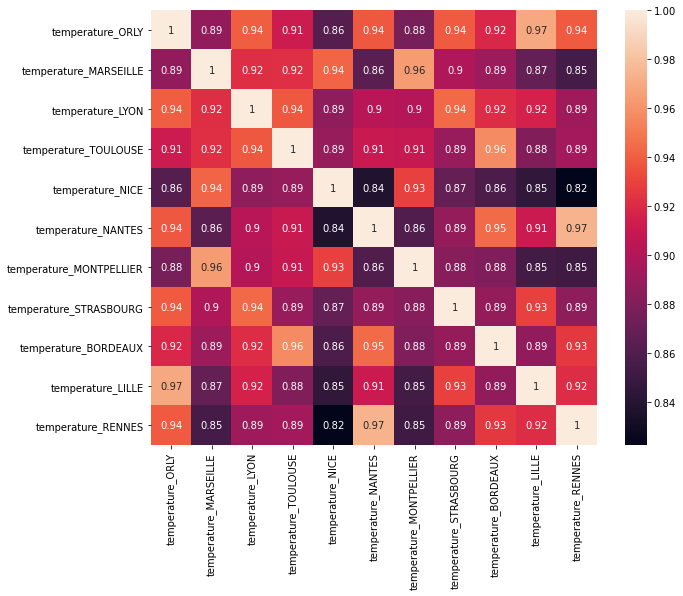

```python
from pandas.plotting import scatter_matrix
import seaborn as sns
import matplotlib.pyplot as plt

fig_t = plt.figure(figsize=(10, 8))
corr = data_temp.corr()

sns.heatmap(corr, annot=True)
plt.show()
```

We can see on the graph above that temperatures are well correlated throughout the territory.

With no surprises, we can notice that highest correlations are obtained for cities located closely (Rennes and Nantes, Montpellier and Marseille, Orly and Lille).

We can therefore as an approximation consider the average of these temperatures without loss of too much information. Thanks to this, we can now establish a link between the temperature over the whole territory and the electricity consumption.

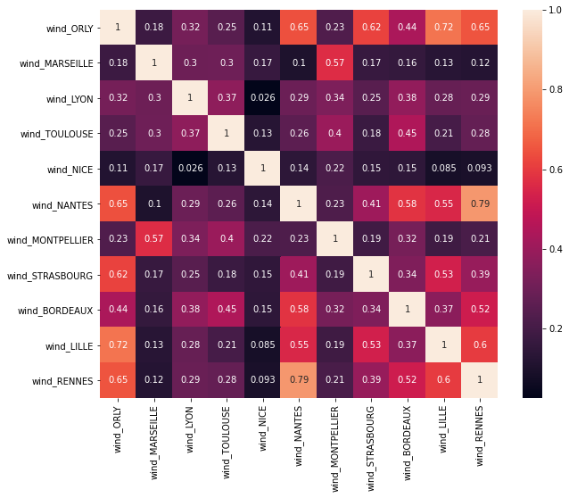

```python
fig_w = plt.figure(figsize=(10, 8))
corr = data_wind.corr()

sns.heatmap(corr, annot=True)
plt.show()
```

Contrary to the temperatures, we can notice that the wind is strongly decreasing in the distance between cities. This data is therefore more local.

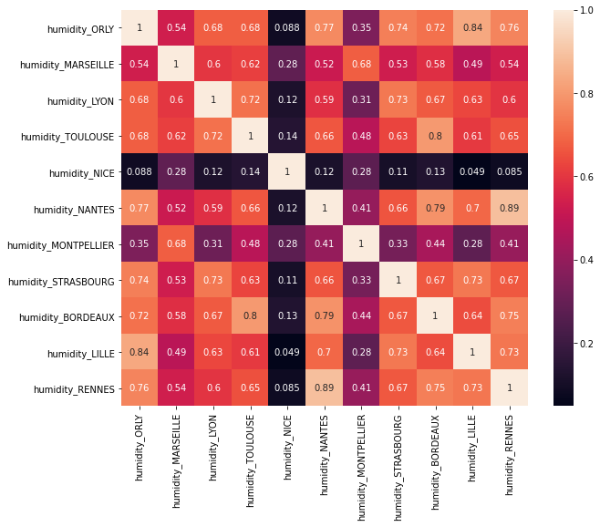

```python
fig_h = plt.figure(figsize=(10, 8))
corr = data_hum.corr()

sns.heatmap(corr, annot=True)
plt.show()
```

Unsurprisingly, the more inland cities are more correlated with each other. Similarly, the humidity of coastal cities is more correlated between them, as between Marseille and Montpellier for example. The humidity can indicate for example the presence of an ocean or a sea nearby. More generally, geography can affect consumption over the whole year.

```python
data['temperature_FRANCE'].corr(data['temperature_ORLY'])
```

```
0.9700400247991213
```

From now, we will take the temperature at Orly as our reference temperature.

We take for the following study the case of temperature only. Indeed, it is logical to think that temperature has a greater impact on the use of heating than either wind or humidity. Moreover, this variable can be expressed in a more global way over the whole territory, where wind and humidity are more local data.

```
-0.10880192384853996
```

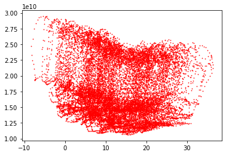

```python
plt.scatter(data['temperature_ORLY'][:17520],
            data['consumption'][:17520], color='r',s=0.5)
data['temperature_ORLY'][:17520].corr(data['consumption'][:17520])
```

There is no correlation between the average temperature in France during the year and the average temperature in France. We'll try to see that over a month. However, the negative sign of the correlation seems to be consistent, the higher the temperature rises and the less energy we consume.

```
0.2615552167089623
```

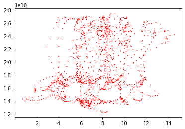

```python
#January 2018
plt.scatter(data['temperature_ORLY'][:1489],
            data['consumption'][:1489], color='r',s=0.5)
data['temperature_ORLY'][:1489].corr(data['consumption'][:1489])
```

We can see that the correlation coefficient increased and became positive. Indeed, on a monthly scale the daily effects become much larger. For example, we consume more electricity during the day when temperatures are warmer than at night. Now let's look at that over a day.

```
0.5187252720714083
```

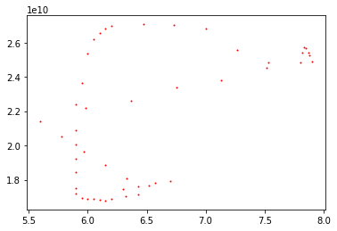

```python
#Between January 11 and 12
plt.scatter(data['temperature_ORLY'][48*10:48*11],
            data['consumption'][48*10:48*11], color='r',s=1)
data['temperature_ORLY'][48*10:48*11].corr(data['consumption'][48*10:48*11])
```

Temperature can be thought to have an effect on electricity consumption over a long period of time. The effects can be seen at the level of the seasons, but it is more complicated to establish results over a shorter period of time. Indeed, while temperatures vary in the month of January, it does not mean for that the heating will be stopped by consumers. Seasonality therefore has a much stronger explanatory potential than temperature, wind or humidity.

# Starting Kit

## Transforming horodate into meaningful features

Transforming horodates into pandas datetime features.

```python
data["horodate"] = pd.to_datetime(data["horodate"])
```

Get periodic functions of date times.

```python
time_in_day = lambda x: (x.hour + x.minute / 60) / 24

data["period_daily_cos"] = data["horodate"].apply(lambda x: np.cos(2 * np.pi * time_in_day(x)))
data["period_daily_sin"] = data["horodate"].apply(lambda x: np.sin(2 * np.pi * time_in_day(x)))
```

```python
time_in_week = lambda x: (x.weekday() + (x.hour + x.minute / 60) / 24) / 7
data["period_weekly_cos"] = data["horodate"].apply(lambda x: np.cos(2 * np.pi * time_in_week(x)))
data["period_weekly_sin"] = data["horodate"].apply(lambda x: np.sin(2 * np.pi * time_in_week(x)))
```

```python
def time_in_year(x):
    seconds_since_beginning_of_year = x - dt.datetime(x.year, 1, 1, tzinfo = x.tzinfo)
    total_seconds_in_year = dt.datetime(x.year, 12, 31, 23, 30, tzinfo = x.tzinfo) - dt.datetime(x.year, 1, 1, tzinfo = x.tzinfo)
    return seconds_since_beginning_of_year / total_seconds_in_year

data["period_yearly_cos"] = data["horodate"].apply(lambda x: np.cos(2 * np.pi * time_in_year(x)))
data["period_yearly_sin"] = data["horodate"].apply(lambda x: np.sin(2 * np.pi * time_in_year(x)))
```

## Simple Random Forest Predictor

```python
from sklearn.ensemble import RandomForestRegressor
```

Defining features and target of our problem. Here target variable is national electric consumption.

```python
X, y = data.iloc[:, 2:], data["consumption"]
```

The problem is to predict national electric consumption in 2020 using past features, ie consumption and features collected in 2018 and 2019.

```python
import datetime
import pytz

threshold = datetime.datetime(2020, 1, 1, 0, 0, 0, 0, pytz.UTC)
print(data[data['horodate'] < threshold])
```

```
                        horodate   consumption  vac_zone_A  vac_zone_B  \
0      2018-01-01 00:00:00+01:00  1.245527e+10           1           1
1      2018-01-01 00:30:00+01:00  1.242073e+10           1           1
2      2018-01-01 01:00:00+01:00  1.234427e+10           1           1
3      2018-01-01 01:30:00+01:00  1.227482e+10           1           1
4      2018-01-01 02:00:00+01:00  1.227774e+10           1           1
...                          ...           ...         ...         ...
35037  2019-12-31 22:30:00+01:00  1.430603e+10           1           1
35038  2019-12-31 23:00:00+01:00  1.410223e+10           1           1
35039  2019-12-31 23:30:00+01:00  1.399484e+10           1           1
35040  2020-01-01 00:00:00+01:00  1.375423e+10           1           1
35041  2020-01-01 00:30:00+01:00  1.370943e+10           1           1

       vac_zone_C  non_working_day  weekend  temperature_ORLY  wind_ORLY  \
0               1                1        0              8.40       7.00
```

[output cut: 51 more lines]

First index of 2020 is located at the 35040th row meaning training features are located at indexes lower than 35040 and testing features are located at indexes larger or equal to 35040.

```python
threshold_2020 = 35040

X_train, y_train = X[:threshold_2020], y[:threshold_2020]
X_test, y_test = X[threshold_2020:], y[threshold_2020:]
```

Defining and training of initial starting kit.

```python
from time import time

start = time()

rf_start_kit = RandomForestRegressor()
rf_start_kit.fit(X_train, y_train)

end = time()

print('Fitting time : ', datetime.timedelta(seconds=end - start))
```

```
Fitting time :  0:01:22.254207
```

Predicting national electric consumption of 2020.

```python
start = time()

y_pred = rf_start_kit.predict(X_test)

end = time()

print('Predicting time : ', datetime.timedelta(seconds=end - start))
```

```
Predicting time :  0:00:00.226741
```

Comparing consumption prediction and true consumption.

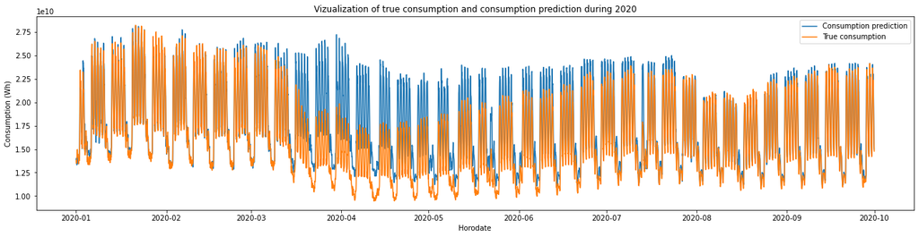

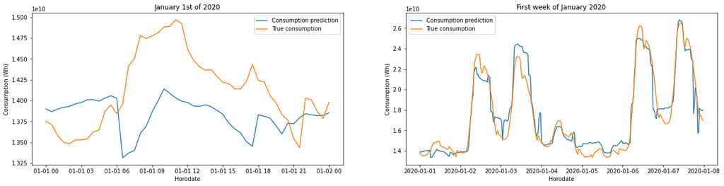

```python
fig1 = plt.figure(figsize=(22, 5))

plt.title('Vizualization of true consumption and consumption prediction during 2020')
plt.xlabel('Horodate')
plt.ylabel('Consumption (Wh)')
plt.plot(data["horodate"][threshold_2020 :], y_pred[:], label = 'Consumption prediction')
plt.plot(data["horodate"][threshold_2020 :], y_test[:], label = 'True consumption')
plt.legend()
plt.show()

fig2, (ax1, ax2) = plt.subplots(1, 2, figsize=(22, 5))

ax1.set_title('January 1st of 2020')
ax1.plot(data["horodate"][threshold_2020 : threshold_2020 + 7 * 7], y_pred[: 7 * 7], label = 'Consumption prediction')
ax1.plot(data["horodate"][threshold_2020 : threshold_2020 + 7 * 7], y_test[: 7 * 7], label = 'True consumption')
ax1.set_xlabel('Horodate')
ax1.set_ylabel('Consumption (Wh)')
ax1.legend()

plt.title('First week of January 2020')
plt.xlabel('Horodate')
plt.ylabel('Consumption (Wh)')
ax2.plot(data["horodate"][threshold_2020 : threshold_2020 + 48 * 7], y_pred[: 48 * 7], label = 'Consumption prediction')
ax2.plot(data["horodate"][threshold_2020 : threshold_2020 + 48 * 7], y_test[: 48 * 7], label = 'True consumption')
ax2.legend()

plt.show()
```

While this simple model presents good enough results overall, it seems clear that it did not adapt very well to the lockdown season (which started on March 17th and ended on the 10th of May in France). This is one of the most challenging parts of this challenge.

Quantifying prediction error using Mean Absolute Relative Error:

```python
from sklearn.utils import check_array

y_true = np.array(y_test).reshape(-1, 1)
y_pred = np.array(y_pred).reshape(-1, 1)

def mean_absolute_relative_error(y_true, y_pred):
    y_true, y_pred = check_array(y_true), check_array(y_pred)

    return np.mean(np.abs((y_true - y_pred) / y_true))


mare = mean_absolute_relative_error(y_true, y_pred)

print('MARE for prediction is ', mare)
```

```
MARE for prediction is  0.09785745431703645
```

We observe a mean absolute relative error of 10% with initial starting kit. Try to do better !

# Submission

To make a RAMP submission, within the directory "submissions" you will need to create a new directory with a file named "estimator.py" that defines a function named "get_estimator" which returns an estimator that performs the desired feature extraction and prediction.

The "estimator.py" of the starting kit is:

```python
import numpy as np
import datetime as dt

from sklearn.base import BaseEstimator
from sklearn.compose import make_column_transformer
from sklearn.ensemble import RandomForestRegressor
from sklearn.pipeline import make_pipeline
from sklearn.preprocessing import FunctionTransformer


class Regressor(BaseEstimator):
    def __init__(self, regressor=RandomForestRegressor(n_estimators=100,
                                                       max_depth=3)):
        self.regressor = regressor

    def fit(self, X, y):
        self.regressor.fit(X, y)
        return self

    def predict(self, X):
        y_pred = self.regressor.predict(X)
        return y_pred


class FeatureExtractor(object):

    def transform(self, X):
        """Create numerical features based on horodate."""
        _X = X.copy()
        # _X["horodate"] = pd.to_datetime(X["horodate"], utc=True)
        _X["period_daily_cos"] = X["horodate"].apply(
            lambda x: np.cos(2 * np.pi * self._time_in_day(x)))
        _X["period_daily_sin"] = X["horodate"].apply(
            lambda x: np.sin(2 * np.pi * self._time_in_day(x)))
        _X["period_weekly_cos"] = X["horodate"].apply(
            lambda x: np.cos(2 * np.pi * self._time_in_week(x)))
        _X["period_weekly_sin"] = X["horodate"].apply(
            lambda x: np.sin(2 * np.pi * self._time_in_week(x)))
        _X["period_yearly_cos"] = X["horodate"].apply(
            lambda x: np.cos(2 * np.pi * self._time_in_year(x)))
        _X["period_yearly_sin"] = X["horodate"].apply(
            lambda x: np.sin(2 * np.pi * self._time_in_year(x)))
        _X.drop(columns="horodate", inplace=True)
        return _X.to_numpy()

    # Utility functions that help converting horodate into meaningful features.
    def _time_in_day(self, x):
        return (x.hour + x.minute / 60) / 24

    def _time_in_week(self, x):
        return (x.weekday() + (x.hour + x.minute / 60) / 24) / 7

    def _time_in_year(self, x):
        scds_since_beginning_year = x - dt.datetime(x.year, 1, 1,
                                                    tzinfo=x.tzinfo)
        total_scds_year = dt.datetime(x.year, 12, 31, 23, 30,
                                      tzinfo=x.tzinfo) - \
            dt.datetime(x.year, 1, 1, tzinfo=x.tzinfo)
        return scds_since_beginning_year / total_scds_year


def get_estimator():
    # transformer
    date_transformer = FunctionTransformer(FeatureExtractor().transform)
    date_cols = ['horodate']

    # preprocessor
    preprocessor = make_column_transformer(
        (date_transformer, date_cols),
        remainder='passthrough',
    )

    # estimator
    regressor = Regressor()

    return make_pipeline(preprocessor, regressor)
```